# Journal–Template

This is what my makefile looks like graphically at the minute:

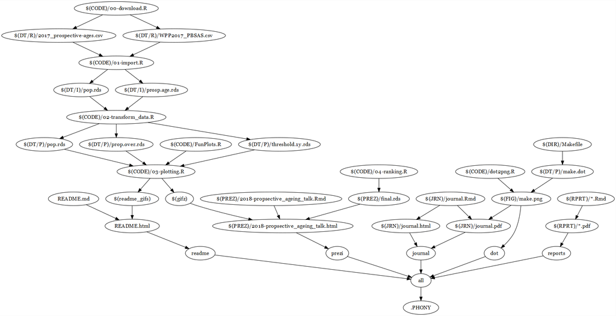

# Monday 12.11.2018

1. Initialise repository.
2. Copy template and start journal
3. Fix Prospective Age repository, there were issues with the code and teh figshare deposit. Now all good.

# Tuesday 13.11.2018

1. Setup this repo.
2. Get list of countries for talk!
3. Revamp `00-download.R` and `01-import.R` from the factsheet ones to fit this project. So download the csv file from figshare and then select only the data for the countries we are interested in and save them in the `interim/data`
4. Install xaringan for the slides. bBause Martin and Yihue say so. Read up on what it is: it is a package that lets you render rmardkown by the remark.js library in the web browser.
5. First read [the remark.js intro](https://remarkjs.com/)
6. Then I apparently need to read the [remark.js Wiki](https://github.com/gnab/remark/wiki), which i have not yet..
7. So xaringan lets you use an rmarkdown file, including code chunks. It knits to html, and you can do gifs, leaflet maps etc that you can’t do in pdfs.
8. Start lit-review

# Wednesday and Thursday 14. and 15.11.2018

1. Contintue reading.
2. check that `01-import.R` works correctly for all countries.
3. also because didn’t have the population data for the pyramids, so update the download script (curl in makefile seems to not work on windows)
4. Now `02-transform.R` update, OK.
5. Now the plotting. But it’s a bit weird, looks like the code is for an older version of the data, before i gathered it all in one table and had names like `threshold_total`. instead it’s still looking for `total`, which doesn’t exist.. I can fix this manually now, of course. But where did it happen, given that the poster is fine!?

# Friday 16.11.2018

1. OK, let’s try if we can get gganimate to work.. So a few things have been learned:
- use `anim_save()` to save gif
- use `animate(p, fps = 10, renderer = gifski_renderer(loop = FALSE))` to control the speed and to make sure the gif doens’t loop, which is what you usually want in a presentation
- use another `geom_line()` with another data to get a ‘background’ to the plot i.e. stuff that doesn’t move.
- Also in `animate()` use width and height to control aspect ratio and resolution - the default seems to be 480x480
2. OK, let’s try a test presentations. Hmm, seems to be some issues with the location of the gif files so here::here() does not work
3. OK, think i’ve figured out the order in ggplot allows me to do the animation over the background lines.
4. Now more ggplot stuff:
- ensure the limits are the same
- increase font size
- different linetypes and sizes `scale_size_manual(values=c(1, 1.5))` and scale_linetype_manual())`
5. OK, clean up the charts a bit more, I need to
- remove the legend
- make the labels larger
- make the main line thicker
- wrap it in a function and pick color scheme back/grey vs red/black
6. Now clean up files and makefile! All works great!
7. Also:
- reduce xlim to more reasonable 1980-2050
- add vertical line at 2015
8. ToDo:
- add animated 65 line? or points at intersections
- Ssth wrong with gif files with spaces in them - not being picked up in xaringan

# Monday 19.11.2018

1. Maybe just add a 65 line simple
2. OK, now proportions over 65. Try to add extra label next to male and female labels.
3. Also, how do i get the first set of lines to stay in the background for the second one. Turns out the trick of just adding a second dataset to a new geom_line works only if the transition variables have a different name, otherwise the `transition_reveal` thing works on both sets. I think I have got it now though.
4. OK, let’s try pyramids… This is tricky..
- Age Grp is character and has 80+ in there..
- can I make over 65 and over threshold a different colour?
- OK, got that, but how do i also add the threshold being a different colour - which changes every year for men and women obvs.
- still something wrong with Belarus, how can the individual male and femaleproportion over thresholds both be higher than the total over threshold
- and why do the pyramid plots all end at 2030!?
5. So the plots can be split into 1980-2015 and 2015-2050, that seems to solve the stopping at 2030, although someone has posted a similar issue, so i’m not going crazy at least, might fix it some other time. https://github.com/thomasp85/tweenr/issues/14
6. Also, Belarus is fine, just weird: It’s because there are separate thresholds and the proportions over the threshold are of women and of men. So there can actually be a situation where there are proportions of men and proportions of women are both higher than the proportion of both over a common threshold, since that common threshold is quite a bit closer to the women’s..

# Tuesday 20/11/2018

1. OK, breaking the populaiton pyramid into two changes the xlim, need to set it manually.
2. Change colurs, add red 65, etc, all good now, plot all pyramid gifs.
3. Add to presentation.
4. Fix spaces in file names.
5. Fix makefile
6. All gifs in presentation.
7. Read Sanderson 2006
8. Read Sanderson 2008
9. Make prospective barchart.

# Wednesday 21.11.2018

1. rearrange the countries
2. get ranking data.
3. Try to deploy on github pages - hmm, not working? rename file to index. html doesn’t do the trick. tried cloning https://github.com/tcgriffith/xaringan_gh, but didn’t fork it or sth, god i hate git. Hopefully it will work ok from the usb. AAW, it worked! just took some time ;)
4. Update makefile
5. Try to get github pages to work from same repo, so don’t have to copy anything. Add index.html into top docs folder.
6. Add notes to presentation.
7. Wrap up for the

moment:

- add readme with a few gifs. Actually make some gifsfor this purpose that loop.
- add loop argument to plot functions.
- add location argument to plot functions
- touch gif files to make make uptodate.
8. ToDo list
- figure out why the population pyramids didn’t work 1980-2050, but needed fewer years?

# 22.11.2018

- Do charts for Ukraine for Katia

# Saturday 24.11.2018

- SHould i write a blog post. It has to mention the figshare data. Should that have dependency ratios as well as just thresholds and proportions over?
- OK, idea: How about comparing three different types of age measurement:
- chronological age. standard, sure. 65 is old or whatever. (absolute from front)
- prospective age. S&S version. RLE15 is old. (absolute from back)
- relative age. 15:65 for example. keep it constant as definition of old age.
- relative no2: keep the ratio of the areas under the survival curve constant. So the ratio of years lived young and old stays the same :D.